# Google Data Analytics R Markdown Notebook

Joseph Venturini

2023-05-15

# Introduction

Over the past few months, I have been pursuing the Google Data Analytics Professional Certificate on Coursera. Throughout the course of this certificate I had the opportunity to utilize software for Data Analytics, including:

- Spreadsheets (Google Sheets and Excel)
- SQL (Structured Query Language)
  - Using Google BigQuery
- R and RStudio

This case study, or capstone project, aims to be a culmination of everything I have learned throughout the course (ha, get it?) of this certification.

## About the company

This case study revolves around a company called Cyclistic, who in 2016 launched a successful bike share offering. The program has grown significantly since, to a fleet of 5,824 bicycles that are geotracked and locked intoo a network of 692 stations across Chicago.

The marketing strategy they currently use provided flexibility in their pricing plans: single-ride passes, full-day passes, and annual memberships. Customers who putchase single-ride or full-day passes are referred to as casual riders. Customers who purchase annual memberships are Cyclistic Members.

After the full data Analytics Process: Ask, Prepare, Process, Analyze, Share, and Act, I hope to achieve an end result– **to be able to recommend marketing strategies to the manager about marketing strategies aiming to convert casual riders into annual members.**

# The Data Analysis Process: Ask, Prepare, Process, Analyze, Share, Act

## Ask

The first phase of the Data Analysis process is to Ask the right questions to make data-driven decisions. What is the problem to be solved here? As mentioned in the introduction, the main goal is to design marketing strategies aimed at converting casual riders into annual members.

Three good questions before even looking at the data are:

1. How do annual members and casual riders use Cyclistic bikes differently?
2. Why would casual riders buy Cyclistic Memberships?
3. How can Cyclistic use digital media to influence casual riders to become members?

## Prepare

I will be analyzing public bike share data found [here](https://divvy-tripdata.s3.amazonaws.com/index.html). The data displayed on the above site is is ordered by month, starting in April 2022, in ascending order every month.

During the SQL courses of the Certificate, a great way to test data for bias and credibility was through an acronym called **ROCCC**.

- Is the data Reliable?
  - As during this case study we are to assume that this data comes from our own company, this data is as reliable as it can get.
- Is the data Original?
  - According to the *About the Company* section, the bikes are geolocated, and the data about their coordinates is sent straight to us. So yes, this data is original.
- Is the data Comprehensive?
  - The data contains various fields of information. In fact, it contains everything we need without missing any defining factors.
- Is the data Current?
  - This data is updated every month. I will be using the period from May 2022 to April 2023. That will be a year’s worth of data leading up to last month. The data is, in fact, current.
- Is the data Cited?
  - Yes. This data is cited and made freely available by Motivate International Inc. under [a license](https://ride.divvybikes.com/data-license-agreement).

We are ready to ROCCC and roll!

I will start by installing the necessary packages. I’ll go ahead and install all packages I have learned about in the certificate:

```r
install.packages("tidyverse")
```

```r
install.packages("ggplot2")
library(tidyverse)
library(ggplot2)
```

- Tidyverse includes many helpful R libraries for Data Analysis
- ggplot2 allows us when we eventually get to visualization of our data.

Next, I will gather and merge all of our data, such that it is all together in one place.

```r
# Gathering data from May 2022 to April 2023
may22 <- read_csv("202205-divvy-tripdata.csv")
jun22 <- read_csv("202206-divvy-tripdata.csv")
jul22 <- read_csv("202207-divvy-tripdata.csv")
aug22 <- read_csv("202208-divvy-tripdata.csv")
sep22 <- read_csv("202209-divvy-tripdata.csv")
oct22 <- read_csv("202210-divvy-tripdata.csv")
nov22 <- read_csv("202211-divvy-tripdata.csv")
dec22 <- read_csv("202212-divvy-tripdata.csv")
jan23 <- read_csv("202301-divvy-tripdata.csv")
feb23 <- read_csv("202302-divvy-tripdata.csv")
mar23 <- read_csv("202303-divvy-tripdata.csv")
apr23 <- read_csv("202304-divvy-tripdata.csv")
# Using rbind command to merge all of this data into one dataframe.
processedBikeData <- rbind(may22, jun22, jul22,
                           aug22, sep22, oct22,
                           nov22, dec22, jan23,
                           feb23, mar23, apr23)
```

With these tasks completed, our data is all in one place and ready for processing.

## Process

Now that all the preparations are done and we have one huge dataset with everything we need, let’s start by checking out all of the features of this dataset: First, we can show the names of the columns in the dataset:

```r
colnames(processedBikeData)
```

```
##  [1] "ride_id"            "rideable_type"      "started_at"
##  [4] "ended_at"           "start_station_name" "start_station_id"
##  [7] "end_station_name"   "end_station_id"     "start_lat"
## [10] "start_lng"          "end_lat"            "end_lng"
## [13] "member_casual"
```

We know that there are only a few columns in this dataset, but in order to learn more about them, let’s look at the structure of the dataset:

```r
str(processedBikeData)
```

```
## spc_tbl_ [5,859,061 × 13] (S3: spec_tbl_df/tbl_df/tbl/data.frame)
##  $ ride_id           : chr [1:5859061] "EC2DE40644C6B0F4" "1C31AD03897EE385" "1542FBEC830415CF" "6FF59852924528F8" ...
##  $ rideable_type     : chr [1:5859061] "classic_bike" "classic_bike" "classic_bike" "classic_bike" ...
##  $ started_at        : POSIXct[1:5859061], format: "2022-05-23 23:06:58" "2022-05-11 08:53:28" ...
##  $ ended_at          : POSIXct[1:5859061], format: "2022-05-23 23:40:19" "2022-05-11 09:31:22" ...
##  $ start_station_name: chr [1:5859061] "Wabash Ave & Grand Ave" "DuSable Lake Shore Dr & Monroe St" "Clinton St & Madison St" "Clinton St & Madison St" ...
##  $ start_station_id  : chr [1:5859061] "TA1307000117" "13300" "TA1305000032" "TA1305000032" ...
##  $ end_station_name  : chr [1:5859061] "Halsted St & Roscoe St" "Field Blvd & South Water St" "Wood St & Milwaukee Ave" "Clark St & Randolph St" ...
##  $ end_station_id    : chr [1:5859061] "TA1309000025" "15534" "13221" "TA1305000030" ...
##  $ start_lat         : num [1:5859061] 41.9 41.9 41.9 41.9 41.9 ...
##  $ start_lng         : num [1:5859061] -87.6 -87.6 -87.6 -87.6 -87.6 ...
##  $ end_lat           : num [1:5859061] 41.9 41.9 41.9 41.9 41.9 ...
##  $ end_lng           : num [1:5859061] -87.6 -87.6 -87.7 -87.6 -87.7 ...
##  $ member_casual     : chr [1:5859061] "member" "member" "member" "member" ...
##  - attr(*, "spec")=
##   .. cols(
##   ..   ride_id = col_character(),
##   ..   rideable_type = col_character(),
##   ..   started_at = col_datetime(format = ""),
##   ..   ended_at = col_datetime(format = ""),
##   ..   start_station_name = col_character(),
##   ..   start_station_id = col_character(),
##   ..   end_station_name = col_character(),
##   ..   end_station_id = col_character(),
##   ..   start_lat = col_double(),
##   ..   start_lng = col_double(),
##   ..   end_lat = col_double(),
##   ..   end_lng = col_double(),
##   ..   member_casual = col_character()
##   .. )
##  - attr(*, "problems")=<externalptr>
```

Let’s see a brief summary of this data:

```r
summary(processedBikeData)
```

```
##    ride_id          rideable_type        started_at
##  Length:5859061     Length:5859061     Min.   :2022-05-01 00:00:06.00
##  Class :character   Class :character   1st Qu.:2022-07-03 11:12:30.00
##  Mode  :character   Mode  :character   Median :2022-08-28 12:44:57.00
##                                        Mean   :2022-09-19 13:39:54.23
##                                        3rd Qu.:2022-11-08 06:30:21.00
##                                        Max.   :2023-04-30 23:59:05.00
##
##     ended_at                      start_station_name start_station_id
##  Min.   :2022-05-01 00:05:17.00   Length:5859061     Length:5859061
##  1st Qu.:2022-07-03 11:38:52.00   Class :character   Class :character
##  Median :2022-08-28 13:07:09.00   Mode  :character   Mode  :character
##  Mean   :2022-09-19 13:58:50.35
##  3rd Qu.:2022-11-08 06:43:39.00
##  Max.   :2023-05-03 10:37:12.00
##
##  end_station_name   end_station_id       start_lat       start_lng
##  Length:5859061     Length:5859061     Min.   :41.64   Min.   :-87.84
##  Class :character   Class :character   1st Qu.:41.88   1st Qu.:-87.66
##  Mode  :character   Mode  :character   Median :41.90   Median :-87.64
##                                        Mean   :41.90   Mean   :-87.65
##                                        3rd Qu.:41.93   3rd Qu.:-87.63
##                                        Max.   :42.07   Max.   :-87.52
##
##     end_lat         end_lng       member_casual
##  Min.   : 0.00   Min.   :-88.14   Length:5859061
##  1st Qu.:41.88   1st Qu.:-87.66   Class :character
##  Median :41.90   Median :-87.64   Mode  :character
##  Mean   :41.90   Mean   :-87.65
##  3rd Qu.:41.93   3rd Qu.:-87.63
##  Max.   :42.37   Max.   :  0.00
##  NA's   :5973    NA's   :5973
```

```r
head(processedBikeData)
```

```
## # A tibble: 6 × 13
##   ride_id          rideable_type started_at          ended_at
##   <chr>            <chr>         <dttm>              <dttm>
## 1 EC2DE40644C6B0F4 classic_bike  2022-05-23 23:06:58 2022-05-23 23:40:19
## 2 1C31AD03897EE385 classic_bike  2022-05-11 08:53:28 2022-05-11 09:31:22
## 3 1542FBEC830415CF classic_bike  2022-05-26 18:36:28 2022-05-26 18:58:18
## 4 6FF59852924528F8 classic_bike  2022-05-10 07:30:07 2022-05-10 07:38:49
## 5 483C52CAAE12E3AC classic_bike  2022-05-10 17:31:56 2022-05-10 17:36:57
## 6 C0A3AA5A614DCE01 classic_bike  2022-05-04 14:48:55 2022-05-04 14:56:04
## # ℹ 9 more variables: start_station_name <chr>, start_station_id <chr>,
## #   end_station_name <chr>, end_station_id <chr>, start_lat <dbl>,
## #   start_lng <dbl>, end_lat <dbl>, end_lng <dbl>, member_casual <chr>
```

Now, I will work with pipes:

```r
processedBikeData <- processedBikeData %>%
  drop_na() %>%
  mutate(trip_length = ended_at - started_at) %>%
  mutate(trip_dayofweek = weekdays(started_at)) %>%
  mutate(trip_month = month(started_at))
processedBikeData
```

```
## # A tibble: 4,533,999 × 16
##    ride_id          rideable_type started_at          ended_at
##    <chr>            <chr>         <dttm>              <dttm>
##  1 EC2DE40644C6B0F4 classic_bike  2022-05-23 23:06:58 2022-05-23 23:40:19
##  2 1C31AD03897EE385 classic_bike  2022-05-11 08:53:28 2022-05-11 09:31:22
##  3 1542FBEC830415CF classic_bike  2022-05-26 18:36:28 2022-05-26 18:58:18
##  4 6FF59852924528F8 classic_bike  2022-05-10 07:30:07 2022-05-10 07:38:49
##  5 483C52CAAE12E3AC classic_bike  2022-05-10 17:31:56 2022-05-10 17:36:57
##  6 C0A3AA5A614DCE01 classic_bike  2022-05-04 14:48:55 2022-05-04 14:56:04
##  7 F2AF43A242DF4555 classic_bike  2022-05-27 12:41:48 2022-05-27 12:50:41
##  8 377BE1F5F0E399CA docked_bike   2022-05-29 19:19:24 2022-05-29 19:31:34
##  9 B136E0C969773F59 classic_bike  2022-05-16 17:48:44 2022-05-16 18:05:26
## 10 75F6A50A05E0AA18 electric_bike 2022-05-11 07:29:29 2022-05-11 07:30:57
## # ℹ 4,533,989 more rows
## # ℹ 12 more variables: start_station_name <chr>, start_station_id <chr>,
## #   end_station_name <chr>, end_station_id <chr>, start_lat <dbl>,
## #   start_lng <dbl>, end_lat <dbl>, end_lng <dbl>, member_casual <chr>,
## #   trip_length <drtn>, trip_dayofweek <chr>, trip_month <dbl>
```

Now, I will move on to analyze this data.

## Analyze

Now that we have processed our data, it is time for analysis.

In the process phase, we know that the member_casual column of our dataset shows whether the rider is a member or casual rider. How many of each are there in our dataset?

```r
memberCount <- processedBikeData %>%
  group_by(member_casual) %>%
  summarise(count=n()) %>%
  mutate(ofTotalPercent = count/sum(count)*100)
memberCount
```

```
## # A tibble: 2 × 3
##   member_casual   count ofTotalPercent
##   <chr>           <int>          <dbl>
## 1 casual        1791114           39.5
## 2 member        2742885           60.5
```

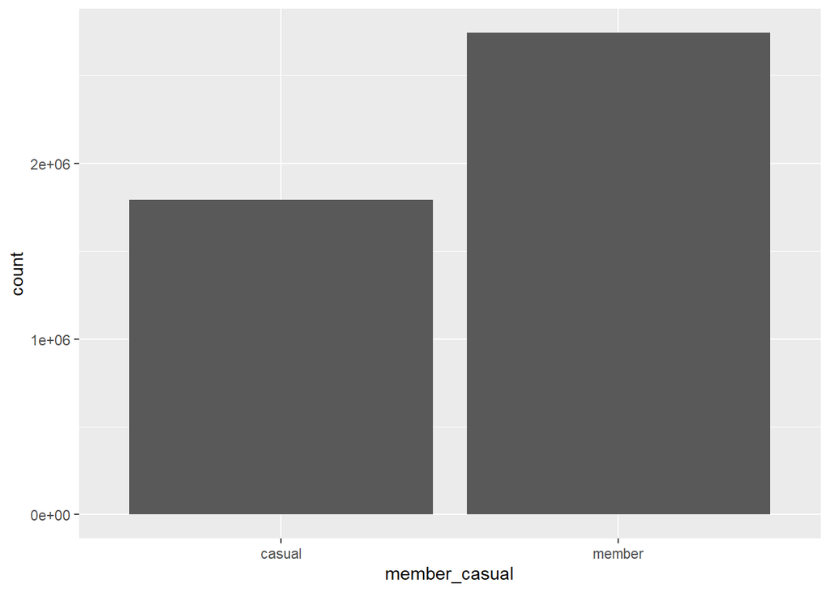

```r
ggplot(data = processedBikeData) +
  geom_bar(mapping=aes(x=member_casual))
```

We have about a 40/60 ratio of casual riders to cyclistic members, which is acceptable enough for analysis. If it were leaning a little more towards one side, I would have reconsidered the data I would have used for this analysis. ’

Another attribute of the dataset is rideable_type, which tells exactly which model of bike the different riders used. Fortunately, we can color-code the above bar chart to make it so that it has different colors for the different bikes shown in our analysis.

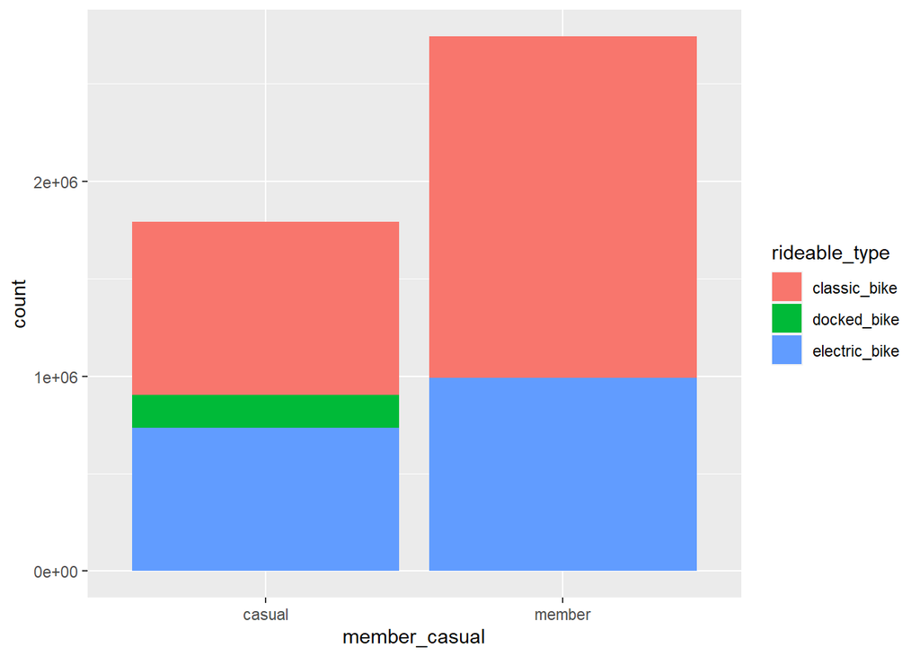

```r
ggplot(data = processedBikeData) +
  geom_bar(mapping=aes(x=member_casual, fill = rideable_type))
```

Right off the bat, we have a few observations thanks to this chart:

- Generally, Classic Bikes are preferred options over Electric bikes.
- Docked Bikes are only used by casual riders.

Something else we measured in the process phase, was the ride length. I will now calculate an average ride length, to hopefully find another difference between Casuals and Members.

```r
meanRide <- processedBikeData %>%
  group_by(member_casual) %>%
  summarise(avg_trip_length = mean(trip_length))
meanRide
```

```
## # A tibble: 2 × 2
##   member_casual avg_trip_length
##   <chr>         <drtn>
## 1 casual        1389.2060 secs
## 2 member         735.2982 secs
```

It looks like casual members seem to have longer bike trips than members do!

We also extracted the day of the week from the datetime object. Let’s see if the day of the week has any correlation:

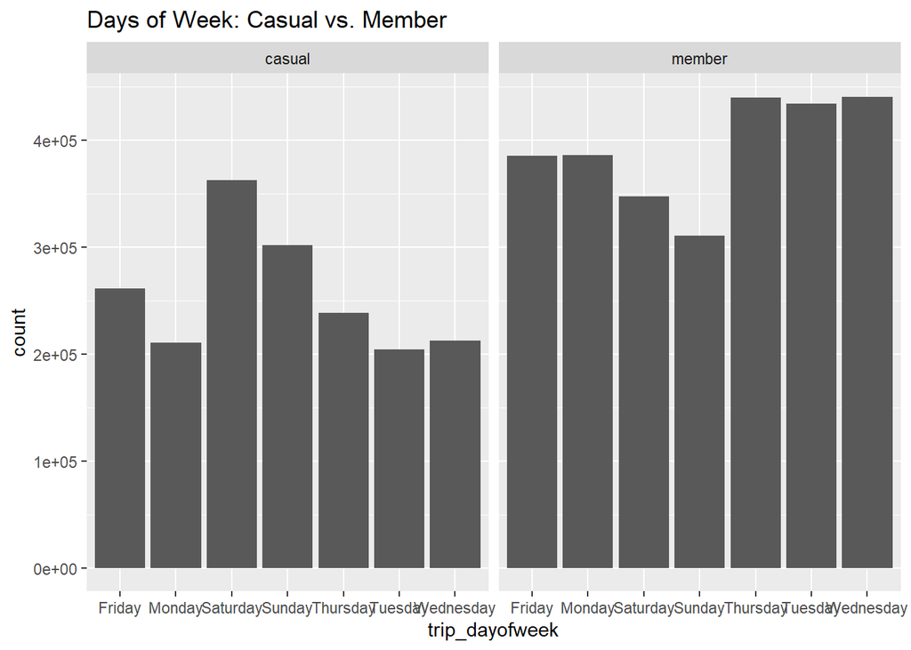

```r
ggplot(data = processedBikeData) +
  geom_bar(mapping = aes(x = trip_dayofweek)) +
  facet_wrap(~member_casual) +
  labs(title = "Days of Week: Casual vs. Member")
```

Another great set of observations to make note of:

- Casual riders prefer weekends (Fridays, Saturdays, Sundays)
- Members prefer riding during the week. (Monday - Friday)

Next, why don’t we measure by month?

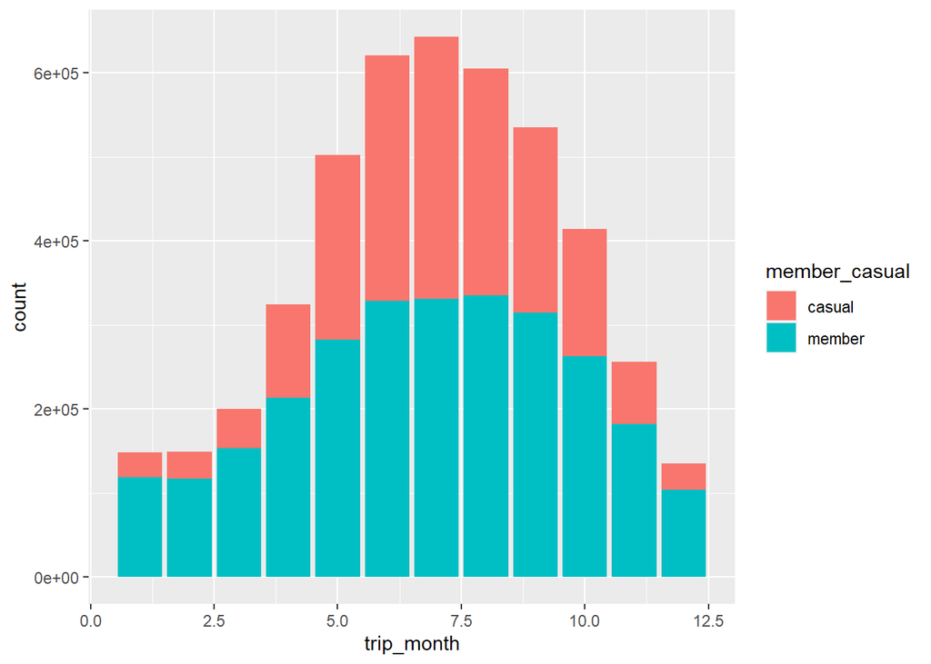

```r
ggplot(data = processedBikeData) +
  geom_bar(mapping=aes(x = trip_month, fill = member_casual))
```

From left to right, we have January through December, respectively. From a general standpoint, a few observations are fair to make here:

- During the Winter, (January, February, and December) bike usage hits its lowest in the entire year.
- During the Spring, (March, April, and May) bike usage starts to pick up at an exponential rate.
- During the Summer, (June, July, and August) bike usage plateaus, averaging more than 600000 riders!
- During the Autumn, (September, October, and November) bike usage starts to decrease, though at a less exponential rate than the gain.